# Some basics of mapping in R

Brittany Barker

2023-11-09

Load all required packages.

```r
library(dplyr) # Data wrangling
library(lubridate) # Working with dates
library(ggplot2) # Plotting model outputs
library(patchwork) # Combine plots
library(viridis) # Color palettes for ggplot2
library(knitr) # Including graphics
library(sf) # Working with spatial features
library(terra) # Working with rasters
# issues w/ installing "USAboundaries" so run this code
#devtools::install_github("ropensci/USAboundaries")
library(USAboundaries) # Boundary features
```

### **Purpose of this demo**

Provide some examples of using the [`terra`](https://rspatial.org/pkg/index.html), [`sf`](https://r-spatial.github.io/sf/), and [`ggplot2`](https://ggplot2.tidyverse.org/) packages to work with geospatial data and create beautiful maps.

### **Mapping predicted vs. observed dates of lilac phenophases**

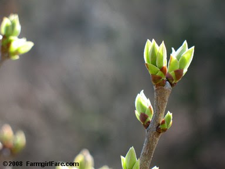

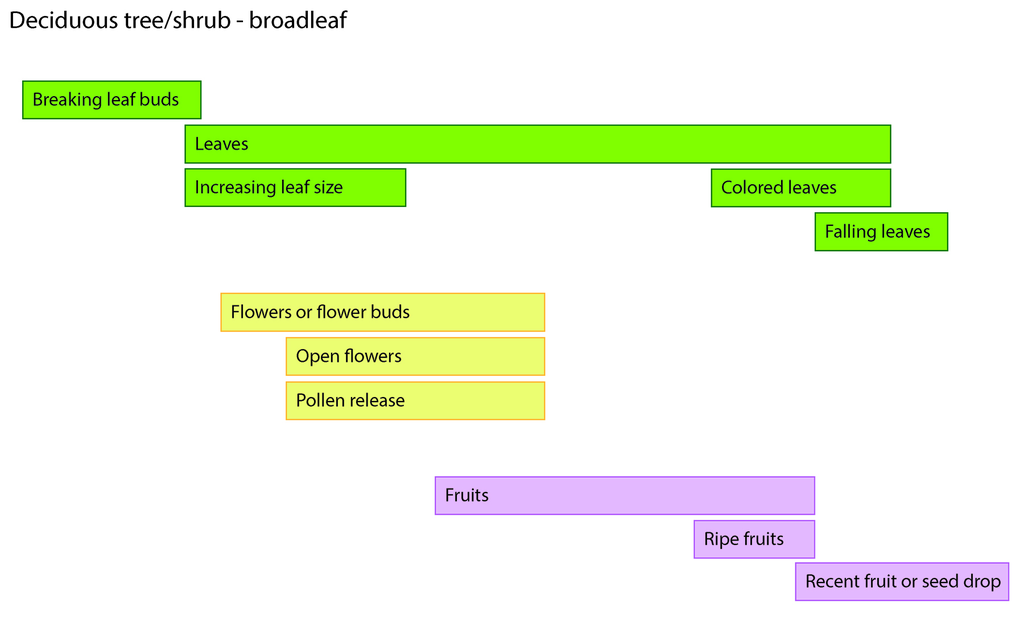

In the following exercises, we will visualize spatial concordance between model-predicted and observed dates of lilac leaf out, which is a phenophase of lilac in which new leaves appear. A **phenophase** is an observable stage of an animal’s or plant’s life cycle that can be defined by a start and end point. All data were derived from the [USA National Phenology Network](https://www.usanpn.org/usa-national-phenology-network), an organization that hosts phenology models and maintains a database of volunteer-contributed observations of phenology for ecologically and economically important species of plants and insects in the USA.

#### **(1) Mapping predicted lilac leaf out**

We import raster data for model predictions of lilac leaf out for 2018 using the `rast()` function in `terra`.

```r
lilacModel <- rast("./data/lilac_2018_model.tiff")
```

The raster is class “SpatRaster”. The raster’s coordinate reference system is “lon/lat NAD83” (often used for North America) and its values range from `6` to `223`, which corresponds the day in which lilac leaf out was predicted to occur in `2018`.

```r
class(lilacModel)
```

```
## [1] "SpatRaster"
## attr(,"package")
## [1] "terra"
```

```r
lilacModel
```

```
## class       : SpatRaster
## dimensions  : 1228, 2606, 1  (nrow, ncol, nlyr)
## resolution  : 0.02246419, 0.02107085  (x, y)
## extent      : -125.0208, -66.47917, 24.0625, 49.9375  (xmin, xmax, ymin, ymax)
## coord. ref. : lon/lat NAD83 (EPSG:4269)
## source      : lilac_2018_model.tiff
## name        : layer
## min value   :     6
## max value   :   223
```

The raster can be visualized using the base `plot()` function in R. This function can produce some decent looking maps, but not nearly as nice as `ggplot2` maps in my opinion. Plants develop slower in colder temperatures, which is why lilac leaf out occurs at later dates in higher-latitude and higher-elevation areas.

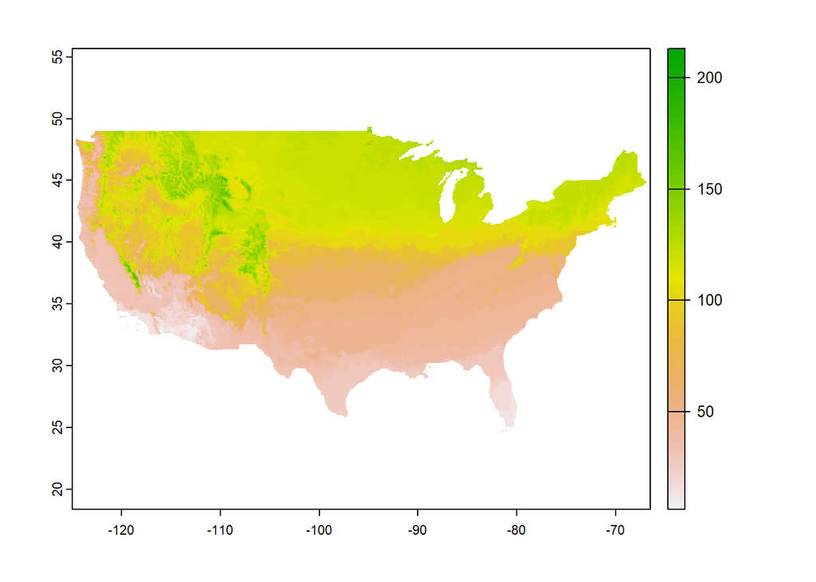

```r
plot(lilacModel)
```

For plotting with `ggplot2`, we convert the raster to a data frame because geoms for gridded data (i.e., `geom_raster()` and `geom_tile()`) require data frames. Additionally, I have found that it’s often easier to manipulate data frames than rasters. However, I just discovered the `tidyterra` package, which has it’s own set of geoms for `ggplot2` (e.g., `geom_spatraster()`)! This is definitely something I’ll investigate further.

Notice that `as.data.frame()` in the `terra` package retains coordinate information (`x` and `y` columns) by setting the `xy` option to `TRUE`.

```r
# Conver raster data to a data frame
lilacModel_df <- terra::as.data.frame(lilacModel, xy = TRUE)
head(lilacModel_df)
```

```
##               x        y layer
## 71692 -95.15470 49.35805   121
## 71693 -95.13223 49.35805   121
## 71694 -95.10977 49.35805   121
## 71695 -95.08731 49.35805   121
## 71696 -95.06484 49.35805   125
## 71697 -95.04238 49.35805   125
```

```r
# Reformat data
lilacModel_df2 <- lilacModel_df %>%
  rename(leaf_out_doy = layer) %>% # New column name
  mutate(leaf_out_date = as.Date(leaf_out_doy, origin = "2018-01-01")) %>% # Convert day of year to calendar date
  group_by(leaf_out_week = factor(lubridate::floor_date(leaf_out_date, 'week'))) %>% # Create bins of dates
  ungroup()
```

Notice that the data frame now has data in numerical (class “num”), date (class “Date”), and categorical (class “factor”) formats.

```r
str(lilacModel_df2)
```

```
## tibble [1,753,552 x 5] (S3: tbl_df/tbl/data.frame)
##  $ x            : num [1:1753552] -95.2 -95.1 -95.1 -95.1 -95.1 ...
##  $ y            : num [1:1753552] 49.4 49.4 49.4 49.4 49.4 ...
##  $ leaf_out_doy : num [1:1753552] 121 121 121 121 125 125 125 125 126 133 ...
##  $ leaf_out_date: Date[1:1753552], format: "2018-05-02" "2018-05-02" ...
##  $ leaf_out_week: Factor w/ 30 levels "2018-01-07","2018-01-14",..: 17 17 17 17 18 18 18 18 18 19 ...
```

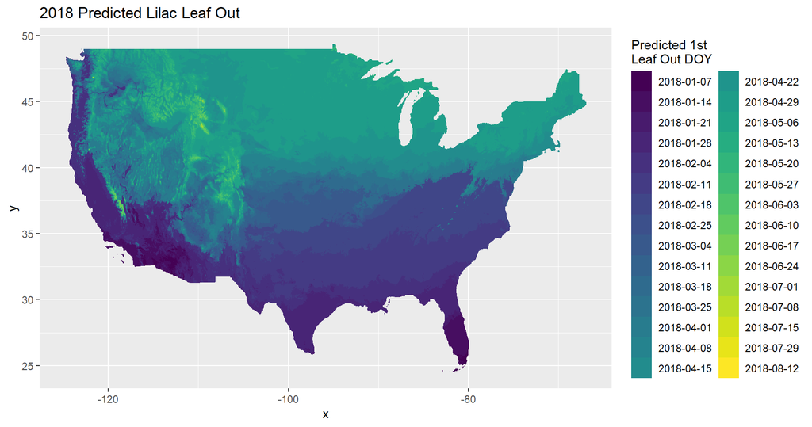

```r
# Create a map using ggplot2
ggplot() +
  geom_raster(data = lilacModel_df2, aes(x = x, y = y, fill = leaf_out_week)) +
  scale_fill_viridis_d("Predicted 1st\nLeaf Out DOY", option = "viridis") +
  ggtitle("2018 Predicted Lilac Leaf Out")
```

This map looks okay, but it would arguably look better without the default gray background, grid lines, and axes features. If you plan on building multiple ggplots, it’s more concise to define your theme a single time rather than repeating it each time you make a new plot.

```r
# Custom theme
my_theme <- theme(panel.grid= element_blank(),
                 panel.background = element_blank(),
                 panel.border = element_blank(),
                 axis.title = element_blank(),
                 axis.text = element_blank(),
                 axis.ticks = element_blank(),
                 title = element_text(face = "bold"),
                 legend.key.size = unit(0.4, "cm"))
```

Apply the custom theme to the plot.

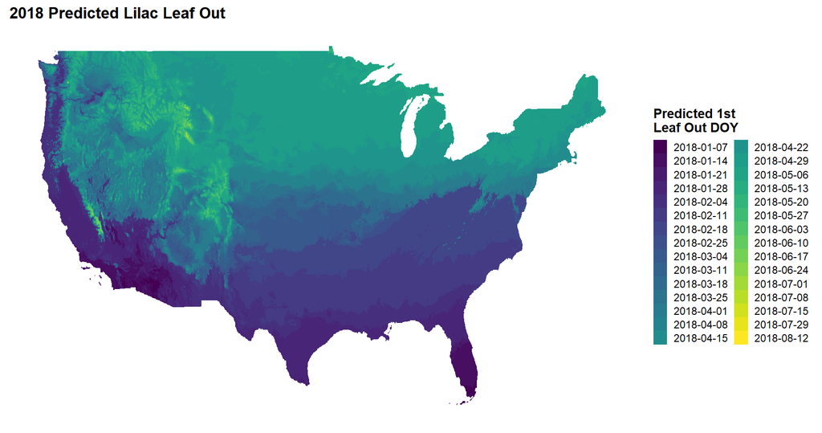

```r
# Create a map using ggplot2
ggplot() +
  geom_raster(data = lilacModel_df2, aes(x = x, y = y, fill = leaf_out_week)) +
  scale_fill_viridis_d("Predicted 1st\nLeaf Out DOY", option = "viridis") +
  ggtitle("2018 Predicted Lilac Leaf Out") +
  my_theme # Our custom theme
```

#### **(2) Adding state features to map**

The map is more informative if we add state boundaries. We’ll use an R package called [`USAboundaries`](https://github.com/ropensci/USAboundaries) to get these data using the `us_states()` function. In the pipeline, we subset data for the contiguous U.S. (CONUS) using `filter()`. The feature is projected to the the NAD83 coordinate reference system and converted to a multi-line string using `st_cast()`.

```r
# Simple feature ("sf") for US states
states <- us_states(resolution = "high") %>%
  filter(jurisdiction_type == "state" & !name %in% c("Alaska", "Hawaii")) %>%
  st_transform(crs = 4269) %>%
  st_cast("MULTILINESTRING")
```

The code block below is the same as above except it adds the `states` feature.

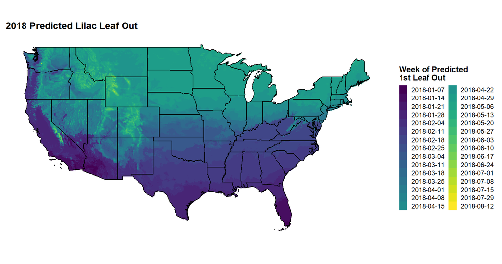

```r
# Create a map using ggplot2
ggplot() +
  geom_raster(data = lilacModel_df2, aes(x = x, y = y, fill = leaf_out_week)) +
  geom_sf(data = states) +
  scale_fill_viridis_d("Week of Predicted\n1st Leaf Out", option = "viridis") +
  ggtitle("2018 Predicted Lilac Leaf Out") +
  my_theme
```

#### **(3) Adding phenometric data to the map**

How do model-predicted dates of lilac leaf out compared with observed dates? To answer this question, we import phenometric data for observed lilac leaf out dates for 2018. These data were collected by volunteers and submitted to the USA National Phenology Network’s database.

```r
# Phenometric data
lilacObs <- read.csv("./data/lilac_2018_obs.csv")
```

Take a look at the data dimensions. We see that there are 182 observations (rows) and 25 variables.

```r
dim(lilacObs)
```

```
## [1] 182  25
```

There are 77 unique sites in the dataset. Our goal is to add data for each of these sites to the map.

```r
length(unique(lilacObs$site_id))
```

```
## [1] 77
```

We only need data in three columns in the phenometric data: `longitude`, `latitude`, and `first_yes_doy`. The `first_yes_doy` column specifies which day of year that lilacs first had leaf out at the site. We’ll subset the columns using `select()` and take a look at the first several rows of data.

```r
lilacObs <- lilacObs %>%
  filter(state != "ON") %>% # Remove an observation from Canada
  dplyr::select("longitude", "latitude", "first_yes_doy") # Subset data by column
```

Take a look at the first several rows of data.

```r
head(lilacObs)
```

```
##   longitude latitude first_yes_doy
## 1 -87.89300 43.09780           121
## 2 -87.89300 43.09780           121
## 3 -92.75200 36.52450            53
## 4 -83.05769 43.72269           118
## 5 -76.55337 38.88813            57
## 6 -76.55337 38.88813            57
```

To match the format of the model-predicted data, day of year is converted to a calendar date and then binned by week of the year.

```r
lilacObs2 <- lilacObs %>%
  mutate(leaf_out_date = as.Date(first_yes_doy, origin = "2018-01-01")) %>%
  group_by(leaf_out_week = factor(lubridate::floor_date(leaf_out_date, 'week')))
```

For plotting purposes, we convert the phenometric data to a simple feature (`sf`) object using the [`st_as_sf()`](https://www.rdocumentation.org/packages/sf/versions/1.0-9/topics/st_as_sf) function. We tell the function which columns contain coordinate information and specify the `crs` argument as [`4269`](https://epsg.io/4269), which corresponds to the NAD83 coordinate reference system.

```r
# Convert data frame to a simple feature
lilacObs_sf <- st_as_sf(lilacObs2, coords = c("longitude", "latitude"), crs = 4269)
```

Now let’s add the phenometric data so we can visualize spatial concordance between model-predicted and observed dates for first leaf out. Sites for each observation are plotted using their coordinate information and colored according to values in the `leaf_out_date` column.

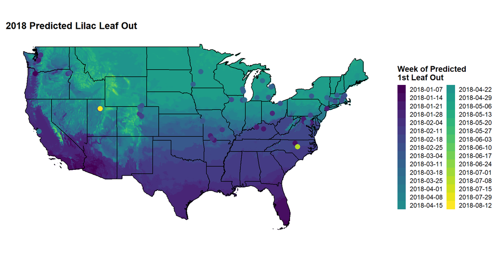

```r
# Add sites to the map
conus_map <- ggplot() +
  geom_raster(data = lilacModel_df2, aes(x = x, y = y, fill = leaf_out_week)) +
  geom_sf(data = states) +
  geom_sf(data = lilacObs_sf, aes(color = leaf_out_date), size = 3, show.legend = FALSE) +
  scale_fill_viridis_d("Week of Predicted\n1st Leaf Out", option = "viridis") +
  scale_color_viridis("Week of Observed\n1st Leaf Out", option = "viridis",
                      guide = guide_colourbar(reverse = TRUE)) +
  ggtitle("2018 Predicted Lilac Leaf Out") +
  my_theme
conus_map
```

#### **(4) Map interpretation**

Our map indicates that observed dates of lilac leaf out in 2018 were often earlier than dates predicted by the model. This suggests that our model tends to over-predict this phenophase, and therefore may need to be calibrated. However, notice that two sites had dates that were much later than predicted dates. In this case, perhaps the volunteers failed to notice that lilac leaf out had already occurred, although other explanations are possible.

#### **(5) Combining maps**

Let’s say we’re interested in results for Michigan and nearby areas in Wisconsin, so we want to create a new map that focuses just on these areas. One way to accomplish this task is to use the `coord_sf()` function, in which the x- and y-limits of the bounding box of interest are defined. We also remove the legend and title.

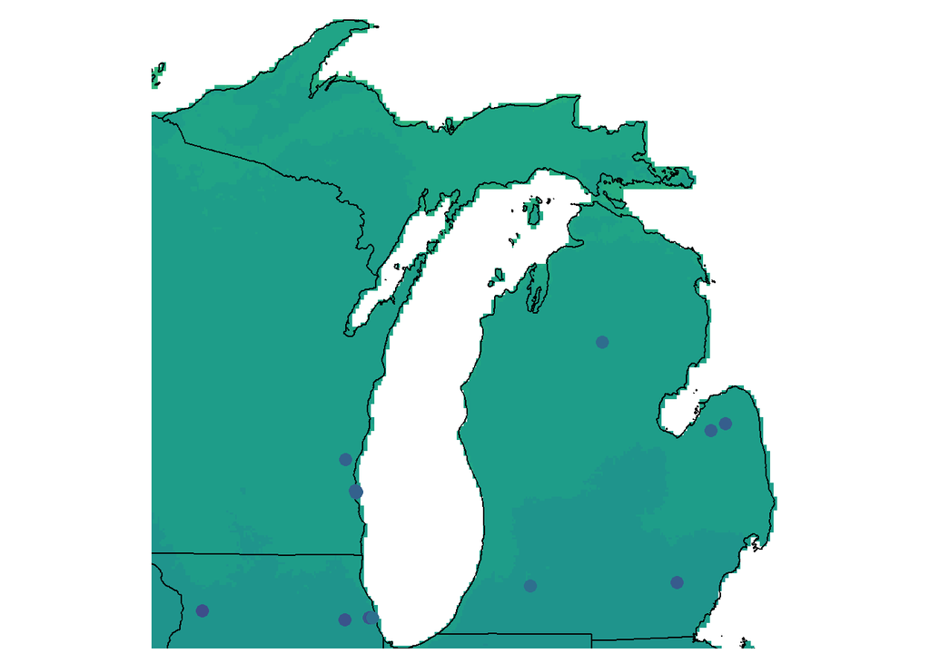

```r
conus_map +
    coord_sf(xlim = c(-90.5542, -82.3047),
           ylim = c(41.6311, 47.5739),
           expand = FALSE) + # Take limits exactly as defined
  theme(legend.position = "none",
        title = element_blank()) # Remove title and legend
```

In our final map, we also add county boundaries for the Michigan region, which can be downloaded via `us_counties()`.

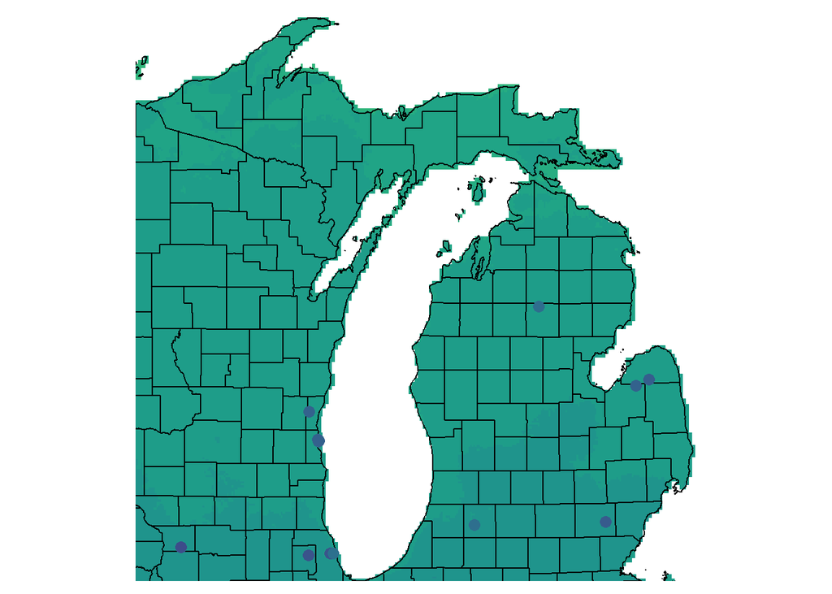

```r
# Simple feature ("sf") for US counties
counties <- us_counties(resolution = "high") %>%
  st_transform(crs = 4269) %>%
  st_cast("MULTILINESTRING")

# Final map for Michigan region
# Lilac leaf out observations are added again so boundary lines don't cover them
mi_map <- conus_map +
  geom_sf(data = counties) + # Add counties
  geom_sf(data = lilacObs_sf, aes(color = leaf_out_date), size = 3, show.legend = FALSE) +
  coord_sf(xlim = c(-90.5542, -82.3047),
           ylim = c(41.6311, 47.5739),
           expand = FALSE) + # Take limits exactly as defined
  theme(legend.position = "none",
        title = element_blank())
mi_map
```

Finally, we can combine maps for CONUS and the Michigan region using the [`patchwork`](https://patchwork.data-imaginist.com/) package. Other options for combining plots include functions in the [`ggpubr`](https://rpkgs.datanovia.com/ggpubr/) (`ggarrange()`) and [`cowplot`](https://cran.r-project.org/web/packages/cowplot/vignettes/introduction.html) (`plot_grid()`) packages. The `\` operator indicates that the map for CONUS goes on top of the Michigan region map, the width setting indicates that the CONUS is map is 2X bigger, and the legend is “collected” to ensure it stays in the correct position (on right-hand side).

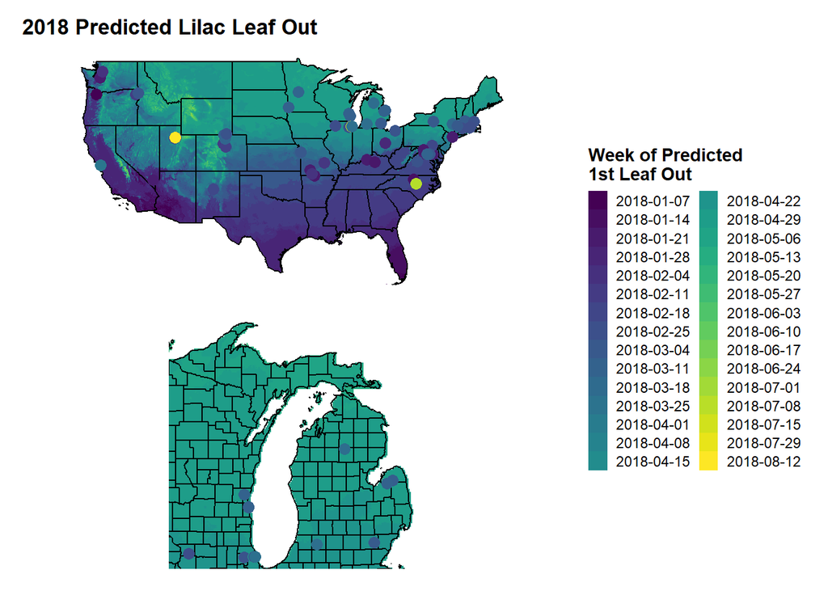

```r
# Combine maps
conus_map / mi_map +
  plot_layout(guides = "collect", widths = c(2, 1))
```

### **Wrap-up**

I only scratched the surface of mapping in R!  
- `ggplot2` has several functions for plotting `sf` objects  
- Raster data can be converted to data frames and plotted  
- However, functions in `tidyterra` can directly plot `SpatRaster` rasters  
- Another option is to convert the raster to a `stars` object and plot it with `geom_stars()`

### **Potentially useful tutorials, free books, etc.**

Compilation of various resources  
- [R Spatial data science blogs](https://r-spatial.org/)

Books  
- [Geocomputation with R](https://r.geocompx.org/) by R. Lovelace et al. (2022)  
- [Geographic Data Science with R](https://bookdown.org/mcwimberly/gdswr-book/) by M.C. Wimberly (2023)  
- [A Crash Course in GIS using R](https://bookdown.org/michael_bcalles/gis-crash-course-in-r/) by M. Branion-Calles (2021)  
- [Data Analysis and Visualization with R: Spatial](http://www.geo.hunter.cuny.edu/~ssun/R-Spatial/) by S. Sun (2023)

Tutorials/vignettes  
- [Spatial Data Science with R and “terra”](https://rspatial.org/) by R. Hijmans (2019-2023)  
- [Geospatial Data Science in R](https://zia207.github.io/geospatial-r-github.io/) by Zia Ahmed  
- [Introduction to GIS with R](https://www.jessesadler.com/post/gis-with-r-intro/) by Jesse Sadler  
- [GIS and Spatial Analysis with R](https://mgimond.github.io/MEGUG2016/Tutorial.html) by Manny Gimmond  
- Vignette for [sf](https://r-spatial.github.io/sf/articles/sf1.html)  
- [R as GIS for Economists](https://tmieno2.github.io/R-as-GIS-for-Economists/create-maps.html) by Taro Mieno